# Intro to CDA in R: Latent Class Analysis

16/12/2019

- Happy New Year!
- Comments on projects (these will be sent by this afternoon)

## Topics for the day

- A review of what we have studied
- Generalized threshold models
- Latent Class Analysis
- Discussion of projects

## Previously on CDA

- Linear, binary, multinomial and ordinal models
- Last models were assuming single index assumption
- Some variable has the same effect at all levels of the distribution of \(y_i\) (e.g. income brings the same happiness across all levels of our happiness construct)

## Generalized Threshold Models

## Threshold models I

- Relax single index assumption
- The idea is to directly model the threshold parameters \(\nu_{ij} = \mu_j + x_{(i)}' \gamma_j\) for \(j=1,...,J\)
- matrix \(x_{(i)}\) excludes a constant
- These will be linear functions of the parameters
- Generalized ordered logit/probit models (depending on specification of link function \(G\))

## Threshold models II

- It is a very flexible alternative
- Parameter estimation of \(\mu_j\) and \(\beta_j\) by ML
- We are interested in the cumulative probability of the event \(\{y_i<j\}\) \[P(y_i<j | x_{(i)})=G(\mu_{j+1}-x_{(i)}'\beta_{j+1})\]

## Threshold models III

- And consequently \[\frac{\partial P(y_i<j | x_{(i)})}{ \partial x_{ik}} = -g(\mu_{j+1}-x_{(i)}'\beta_{j+1})\beta_{{j+1},k}\]
- We no longer impose the assumption of parallel regressions so that \(MPE_{ijk}/MPE_{ijh}\) are not constant anymore; these vary but do not cross
- This model is more computationally demanding

## Item Response Theory (IRT)

## IRT

- It is central to the analysis of standardized tests (e.g. PISA)
- There are many IRT models
- \(x_{im}\): response of \(m\)-th subject in the \(i\)-th item
- \(z_m\): latent variable (e.g., latent ability); and we assume that \(z_m \in (− \infty, \infty)\)
- Model the relation between the probability of a positive (e.g., correct) response and subjects *unobserved* or latent ability \(z_m\) \[Pr(x_{im} = 1|z_m; \theta)\] with \(\theta\) being the parameter which describes this relation
- Examples: Three parameter logistic model, Rasch model, models for polytomous data and many many more

## Latent Class Analysis

## Basics

- Manifest vs. Latent
- Suited for analyzing multivariate categorical data
- Investigate sources of confounding between observed variables
- Stratify contingency tables by an unobserved, unordered categorical variable (i.e. nominal) which eliminates all confounding sources between observed variables

## Conditional or local independence

- Conditional probability function \[\mathbb{P}(y_i|x_i)=f(y_i|x_i;\theta)\]
- So in LCA, we say that conditioning on values of the latent variable, responses to all observed variables are *assumed* to be statistically independent

## Assumption of LCA

- The presence of an underlying, unobserved *latent categorical* variable to explain patterns among observed variables
- Each observation is probabilistically grouped in a latent class
- Finite mixture model: cross-classification tables are the distributions that compose this model
- Parameters estimated by the latent class model are:
1. the proportion of observations in each latent class
2. the probabilities of observing each response to each manifest variable, contditional on latent class

## Confounding

- What is confounding?
- This is a causal concept

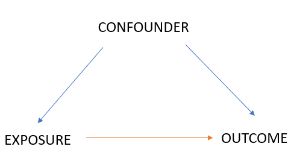

- A confounder (also confounding variable, confounding factor, or lurking variable) is a variable that influences both the dependent variable and independent variable, causing a spurious association.

## Latent class analysis as DAG

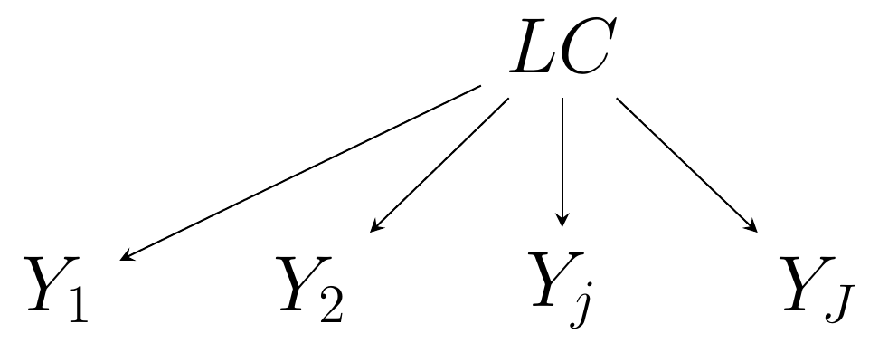

- By adjusting for the unobserved latent class, we will break the association between the different categorical items
- How? By grouping observations into categories (stratifying)

## Limitations

- How many classes or groups?
- Criteria: parsimony and goodness of fit statistics

## The model I

- we observe \(J\) polytomous categorical variables
- each contains \(K_j\) possible outcomes, for individuals \(i= 1,...,N\).
- Manifest variables may have different numbers of outcomes, hence the indexing by j.
- \(Y_{ijk}\) the observed values of the \(J\) manifest variables such that \(Y_{ijk}= 1\) if respondent \(i\) gives the \(k\)-th response to the \(j\)-th variable, and \(Y_{ijk}= 0\) otherwise, where \(j= 1,...,J\) and \(k= 1,...,K_j\)

## The model II

- \(π_{jrk}\) denotes the class-conditional probability that an observation in class \(r= 1,...,R\) produces the \(k\)-th outcome on the \(j\)-th variable.
- Within each \(r\) class, for each manifest variable, therefore, \(\sum_{k=1}^{K_j} π_{jrk} = 1\). Further denote as \(p_r\) the \(R\) mixing proportions that provide the weights in the weighted sum of the component tables,with \(\sum_r p_r = 1\).
- Values of \(p_r\) are “prior” probabilities of latent class membership (unconditional probability that an individual will belong to each class before taking into account the responses \(Y_{ijk}\)

## The model III

- We arrive at the probability that an individual \(i\) in class \(r\) produces a particular set of \(J\) responses on the observed variables:

\[f(Y_i;\pi_r)=\prod_{j=1}^J \prod_{k=1}^{K_j} (\pi_{jrk})^{Y_{ijk}}\] - Across all classes, the PDF is a weighted sum \[P(Y_i | \pi,p) = \sum_{r=1}^J p_r \prod_{j=1}^J \prod_{k=1}^{K_j} (\pi_{jrk})^{Y_{ijk}}\]

## The model IV

- We want to estimate parameters \(p_r\) and \(\pi_{jrk}\)
- With the estimates we can compute the “posterior” probability that each individual belongs to each class as: \[\hat{P}(r_i|Y_1) = \frac{\hat{p_r} f(Y_i;\hat{\pi}_r)}{\sum_{q=1}^R \hat{p_q}f(Y_i;\hat{\pi}_q)}\]

## Estimation I

- Number of parameters depends on \(R\), \(J\) and \(K_j\), so it can increase rapidly
- Number of parameters \(R\sum_j(K_j-1)+(R-1)\) cannot exceed \(N\)
- Expectation-maximization algorithm: maximize \[\ln L = \sum_{i=1}^N \ln \sum_{r=1}^R p_r \prod_{j=1}^J \prod_{k=1}^{K_j} (\pi_{jrk})^{Y_{ijk}}\] with respect to \(p_r\) and \(\pi_{jrk}\)

## Estimation II

- This log-likelihood function is identical in form to the standard finite mixture model log-likelihood.
- As with any finite mixture model, the EM algorithmis applicable because each individual’s class membership is unknown and may be treated as missing data
- missing values can be handled by the EM algorithm
- it is always advisable to re-estimate a particular model a couple of times when using poLCA, in an attempt to find the global maximizer to be taken as the maximum likelihood solution.
- We also obtained standard errors for the parameters of this model

## Number of classes I

- assessing model fit and determining anappropriate number of latent classesRfor a given data set
- Theoretical reasons
- Locate the best fitting, or the most parsimonious model
- How? begin by fitting a complete“independence” model withR= 1, and then iteratively increasing the number of latentclasses by one until a suitable fit has been achieved

## Number of classes II

- Parsimony criteria seek to strike a balance between over- and under-fitting the model
- Idea: penalizing the log-likelihood by the number of parameters
- Bayesian information criterion (BIC) and Akaike information criterion (AIC)
- Criteria: chose model that minimizes values of the BIC and/or AIC

## Number of classes III

- Pearson \(\chi^2\) or likelihood ratio (\(G^2\)) statistics
- Idea: compare the observed versus predicted cell counts
- Criteria: select models that minimize \(\chi^2\) or \(G^2\) without too many parameters
- Limitation: strong distributional assumptions (not useful when contingency tables have many empty cells)

## Discussion of Projects

## Ideal Structure for 10 CP

- “Hausarbeit” of a 20-25 pages length
- Provide a motivation
- Some theoretical reflections
- Emphasize the method: why is suited? why not other alternatives?
- Describe the data! (tables and plots)
- Appropriate Interpretation of results of the chosen model
- Ideally: compare different modeling alternatives
- Discuss what results mean in light of the theory selected
- Conclude: what did you find out?

## Ideal Structure for 5 CP

- “Essay” of 10-15 pages length
- Motivate the topic (but avoid theory)
- Emphasize the method: why is suited? why not other alternatives?
- Describe the data! (tables and plots)
- Appropriate Interpretation of results of the chosen model
- Ideally: compare different modeling alternatives
- Conclude: what did you find out?

## Next time on CDA

- Latent class regression models
- Count data models
- Boosting